# Homework 9

**Due: 2022-4-21, 10:30am**

# Logistic Regression

We will use the admission data in this problem. A researcher is interested in how variables, such as GRE (Graduate Record Exam scores), GPA (grade point average) and prestige of the undergraduate institution, effect admission into graduate school. The response variable, admit/don’t admit, is a binary variable.

```r
mydata <- read.csv("https://stats.idre.ucla.edu/stat/data/binary.csv")
head(mydata)
```

```
##   admit gre  gpa rank
## 1     0 380 3.61    3
## 2     1 660 3.67    3
## 3     1 800 4.00    1
## 4     1 640 3.19    4
## 5     0 520 2.93    4
## 6     1 760 3.00    2
```

1. (5%) First, please convert `rank` and `admit` to factors to indicate that they should be treated as categorical variables.

```r
mydata$rank <- factor(mydata$rank)
mydata$admit <- factor(mydata$admit)
```

2. (5%) Second, please split the data into training (60%) and validation (40%).

```r
library(caret)
set.seed(123)
inTrain <- createDataPartition(y = mydata$admit, p = .60, list = FALSE)
training <- mydata[inTrain,]
validation <- mydata[-inTrain,]
dim(training)
```

```
## [1] 241   4
```

```r
dim(validation)
```

```
## [1] 159   4
```

3. (10%) Third, in training data, please build the model to predict admit using logistic regression (predictors include `gre`, `gpa`, and `rank`).

```r
mylogit <- glm(admit ~ gre + gpa + rank, data = training, family = "binomial")
summary(mylogit)
```

```
##
## Call:
## glm(formula = admit ~ gre + gpa + rank, family = "binomial",
##     data = training)
##
## Deviance Residuals:
##     Min       1Q   Median       3Q      Max
## -1.5854  -0.8851  -0.5830   1.0542   2.2156
##
## Coefficients:
##              Estimate Std. Error z value Pr(>|z|)
## (Intercept) -5.975430   1.538581  -3.884 0.000103 ***
## gre          0.002025   0.001425   1.421 0.155315
## gpa          1.369921   0.434101   3.156 0.001601 **
## rank2       -0.389270   0.416836  -0.934 0.350371
## rank3       -1.153427   0.447809  -2.576 0.010003 *
## rank4       -1.625632   0.605372  -2.685 0.007246 **
## ---
## Signif. codes:  0 '***' 0.001 '**' 0.01 '*' 0.05 '.' 0.1 ' ' 1
##
## (Dispersion parameter for binomial family taken to be 1)
##
##     Null deviance: 301.97  on 240  degrees of freedom
## Residual deviance: 269.86  on 235  degrees of freedom
## AIC: 281.86
##
## Number of Fisher Scoring iterations: 4
```

4. (15%) Fourth, using validation data, predict the probability of getting admission and classify the prediction based on cut-off value of 0.5.

```r
# Predict the probability of getting admission
admit_prob <- predict(mylogit, validation, type="response")
# Classification based on a cut-off value
admit_pred <- rep("0", dim(validation)[1])
admit_pred[admit_prob > .5] = "1"
```

5. (15%) Last, check the performance using both confusion matrix and ROC curve.

```r
table(admit_pred, validation$admit)
```

```
##
## admit_pred  0  1
##          0 96 39
##          1 13 11
```

```r
library(pROC)
roc.info <- roc(validation$admit, admit_prob)
```

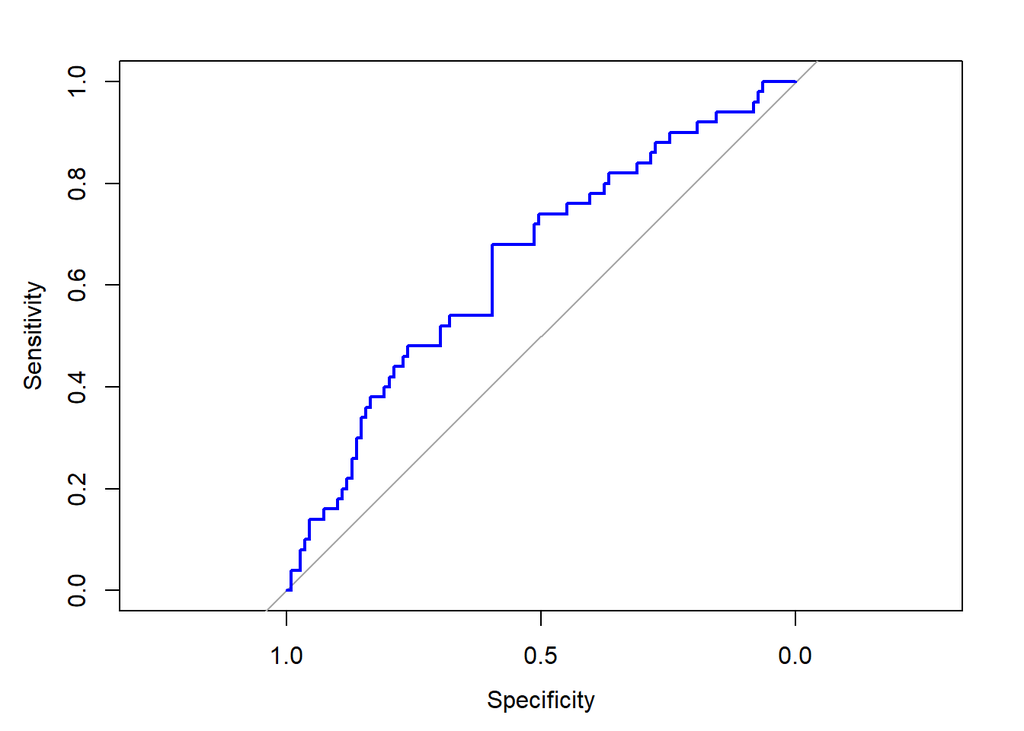

```r
plot(roc.info,col = "blue")
```

# Decision Trees

We will apply decision tree to predict survival using the Titanic data.

Preparing the Data

```r
path <- 'https://raw.githubusercontent.com/guru99-edu/R-Programming/master/titanic_data.csv'
titanic <-read.csv(path, na.strings = "?")
head(titanic)
```

```
##   x pclass survived                                            name    sex
## 1 1      1        1                   Allen, Miss. Elisabeth Walton female
## 2 2      1        1                  Allison, Master. Hudson Trevor   male
## 3 3      1        0                    Allison, Miss. Helen Loraine female
## 4 4      1        0            Allison, Mr. Hudson Joshua Creighton   male
## 5 5      1        0 Allison, Mrs. Hudson J C (Bessie Waldo Daniels) female
## 6 6      1        1                             Anderson, Mr. Harry   male
##       age sibsp parch ticket     fare   cabin embarked
## 1 29.0000     0     0  24160 211.3375      B5        S
## 2  0.9167     1     2 113781 151.5500 C22 C26        S
## 3  2.0000     1     2 113781 151.5500 C22 C26        S
## 4 30.0000     1     2 113781 151.5500 C22 C26        S
## 5 25.0000     1     2 113781 151.5500 C22 C26        S
## 6 48.0000     0     0  19952  26.5500     E12        S
##                         home.dest
## 1                    St Louis, MO
## 2 Montreal, PQ / Chesterville, ON
## 3 Montreal, PQ / Chesterville, ON
## 4 Montreal, PQ / Chesterville, ON
## 5 Montreal, PQ / Chesterville, ON
## 6                    New York, NY
```

```r
tail(titanic)
```

```
##         x pclass survived                      name    sex  age sibsp parch
## 1304 1304      3        0     Yousseff, Mr. Gerious   male   NA     0     0
## 1305 1305      3        0      Zabour, Miss. Hileni female 14.5     1     0
## 1306 1306      3        0     Zabour, Miss. Thamine female   NA     1     0
## 1307 1307      3        0 Zakarian, Mr. Mapriededer   male 26.5     0     0
## 1308 1308      3        0       Zakarian, Mr. Ortin   male 27.0     0     0
## 1309 1309      3        0        Zimmerman, Mr. Leo   male 29.0     0     0
##      ticket    fare cabin embarked home.dest
## 1304   2627 14.4583  <NA>        C      <NA>
## 1305   2665 14.4542  <NA>        C      <NA>
## 1306   2665 14.4542  <NA>        C      <NA>
## 1307   2656  7.2250  <NA>        C      <NA>
## 1308   2670  7.2250  <NA>        C      <NA>
## 1309 315082  7.8750  <NA>        S      <NA>
```

```r
# Drop some variables
clean_titanic <- subset(titanic,select = -c(home.dest, cabin, name, x, ticket))
clean_titanic$sex <- factor(clean_titanic$sex)
clean_titanic$pclass <-  factor(clean_titanic$pclass, levels = c(1, 2, 3), labels = c('Upper', 'Middle', 'Lower'))
clean_titanic$survived <- factor(clean_titanic$survived, levels = c(0, 1), labels = c('No', 'Yes'))
clean_titanic$age <- as.numeric(clean_titanic$age)
clean_titanic$sibsp <- as.numeric(clean_titanic$sibsp)
clean_titanic$parch <- as.numeric(clean_titanic$parch)
clean_titanic$fare <- as.numeric(clean_titanic$fare)
clean_titanic$embarked <- factor(clean_titanic$embarked)
clean_titanic=na.omit(clean_titanic)
head(clean_titanic)
```

```
##   pclass survived    sex     age sibsp parch     fare embarked
## 1  Upper      Yes female 29.0000     0     0 211.3375        S
## 2  Upper      Yes   male  0.9167     1     2 151.5500        S
## 3  Upper       No female  2.0000     1     2 151.5500        S
## 4  Upper       No   male 30.0000     1     2 151.5500        S
## 5  Upper       No female 25.0000     1     2 151.5500        S
## 6  Upper      Yes   male 48.0000     0     0  26.5500        S
```

6. (5%) Randomly split data into training (70%) and validation (30%).

```r
set.seed(678)
train.idx <- sample(nrow(clean_titanic), 0.7*nrow(clean_titanic))
tit.train <- clean_titanic[train.idx,]
tit.valid <- clean_titanic[-train.idx,]
table(tit.train$survived)
```

```
##
##  No Yes
## 424 306
```

```r
table(tit.valid$survived)
```

```
##
##  No Yes
## 194 119
```

7. (10%) Using training data, build decision trees to predict survival using `rpart()` function from `rpart` package.

```r
library(rpart)
set.seed(1234)
dtree <- rpart(survived ~ ., data=tit.train, method="class",
               parms=list(split="information"))
```

8. (15%) Choose the complexity parameter (CP) to prune the decision tree.

```r
dtree$cptable
```

```
##           CP nsplit rel error    xerror       xstd
## 1 0.46078431      0 1.0000000 1.0000000 0.04356731
## 2 0.01307190      1 0.5392157 0.5392157 0.03693034
## 3 0.01143791      4 0.5000000 0.5326797 0.03677075
## 4 0.01000000      9 0.4346405 0.5163399 0.03636166
```

```r
min.idx=which.min(dtree$cptable[,"xerror"])
(choice.range=c(dtree$cptable[min.idx,"xerror"]-dtree$cptable[min.idx,"xstd"],dtree$cptable[min.idx,"xerror"]+dtree$cptable[min.idx,"xstd"]))
```

```
## [1] 0.4799782 0.5527015
```

```r
(choice.rowidx=which(dtree$cptable[,"xerror"]> choice.range[1] & dtree$cptable[,"xerror"]< choice.range[2])[1])
```

```
## 2
## 2
```

```r
(CP_choice=dtree$cptable[choice.rowidx,"CP"])
```

```
## [1] 0.0130719
```

9. (10%) Prunes the tree using the `CP` you choose in Question 8 and plot the pruned decision tree using `prp()` from `rpart.plot` package.

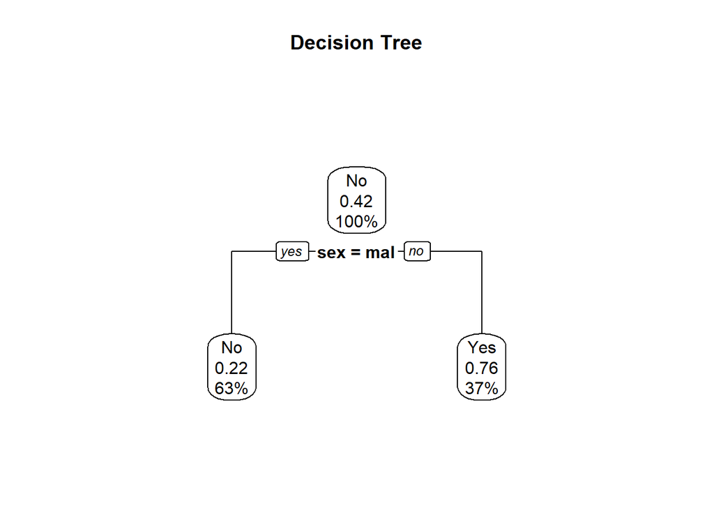

```r
dtree.pruned <- prune(dtree, cp=CP_choice)
# Plot an rpart model.
library(rpart.plot)
prp(dtree.pruned, type = 2, extra = "auto" ,
    fallen.leaves = TRUE, main="Decision Tree")
```

10. (10%) Using validation data, predict survival and check the performance using confusion matrix.

```r
dtree.pred <- predict(dtree.pruned, tit.valid, type="class")
dtree.perf <- table(tit.valid$survived, dtree.pred,
                      dnn=c("Actual", "Predicted"))
dtree.perf
```

```
##       Predicted
## Actual  No Yes
##    No  164  30
##    Yes  36  83
```